# Overview

Dataset info

| Number of variables | 13 |
| --- | --- |
| Number of observations | 517 |
| Total Missing (%) | 0.0% |
| Total size in memory | 52.6 KiB |
| Average record size in memory | 104.2 B |

Variables types

| Numeric | 11 |
| --- | --- |
| Categorical | 2 |
| Boolean | 0 |
| Date | 0 |
| Text (Unique) | 0 |
| Rejected | 0 |
| Unsupported | 0 |

Warnings

- `rain` has 509 / 98.5% zeros Zeros
- `area` has 247 / 47.8% zeros Zeros
- Dataset has 4 duplicate rows Warning

# Variables

X  
Numeric

| Distinct count | 9 |
| --- | --- |
| Unique (%) | 1.7% |
| Missing (%) | 0.0% |
| Missing (n) | 0 |
| Infinite (%) | 0.0% |
| Infinite (n) | 0 |

| Mean | 4.6692 |
| --- | --- |
| Minimum | 1 |
| Maximum | 9 |
| Zeros (%) | 0.0% |

Toggle details

**Statistics**

Quantile statistics

| Minimum | 1 |
| --- | --- |
| 5-th percentile | 1 |
| Q1 | 3 |
| Median | 4 |
| Q3 | 7 |
| 95-th percentile | 8 |
| Maximum | 9 |
| Range | 8 |
| Interquartile range | 4 |

Descriptive statistics

| Standard deviation | 2.3138 |
| --- | --- |
| Coef of variation | 0.49554 |
| Kurtosis | -1.1723 |
| Mean | 4.6692 |
| MAD | 2.0259 |
| Skewness | 0.036246 |
| Sum | 2414 |
| Variance | 5.3536 |
| Memory size | 4.2 KiB |

**Histogram**

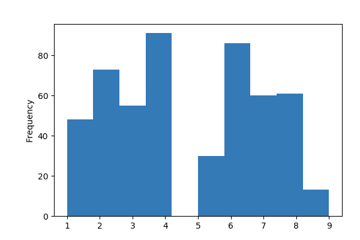

**Common Values**

| Value | Count | Frequency (%) |  |
| --- | --- | --- | --- |
| 4 | 91 | 17.6% |  |
| 6 | 86 | 16.6% |  |
| 2 | 73 | 14.1% |  |
| 8 | 61 | 11.8% |  |
| 7 | 60 | 11.6% |  |
| 3 | 55 | 10.6% |  |
| 1 | 48 | 9.3% |  |
| 5 | 30 | 5.8% |  |
| 9 | 13 | 2.5% |  |

**Extreme Values**

Minimum 5 values

| Value | Count | Frequency (%) |  |
| --- | --- | --- | --- |
| 1 | 48 | 9.3% |  |
| 2 | 73 | 14.1% |  |
| 3 | 55 | 10.6% |  |
| 4 | 91 | 17.6% |  |
| 5 | 30 | 5.8% |  |

Maximum 5 values

| Value | Count | Frequency (%) |  |
| --- | --- | --- | --- |
| 5 | 30 | 5.8% |  |
| 6 | 86 | 16.6% |  |
| 7 | 60 | 11.6% |  |
| 8 | 61 | 11.8% |  |
| 9 | 13 | 2.5% |  |

Y  
Numeric

| Distinct count | 7 |
| --- | --- |
| Unique (%) | 1.4% |
| Missing (%) | 0.0% |
| Missing (n) | 0 |
| Infinite (%) | 0.0% |
| Infinite (n) | 0 |

| Mean | 4.2998 |
| --- | --- |
| Minimum | 2 |
| Maximum | 9 |
| Zeros (%) | 0.0% |

Toggle details

**Statistics**

Quantile statistics

| Minimum | 2 |
| --- | --- |
| 5-th percentile | 2 |
| Q1 | 4 |
| Median | 4 |
| Q3 | 5 |
| 95-th percentile | 6 |
| Maximum | 9 |
| Range | 7 |
| Interquartile range | 1 |

Descriptive statistics

| Standard deviation | 1.2299 |
| --- | --- |
| Coef of variation | 0.28604 |
| Kurtosis | 1.4206 |
| Mean | 4.2998 |
| MAD | 0.9487 |
| Skewness | 0.4173 |
| Sum | 2223 |
| Variance | 1.5127 |
| Memory size | 4.2 KiB |

**Histogram**

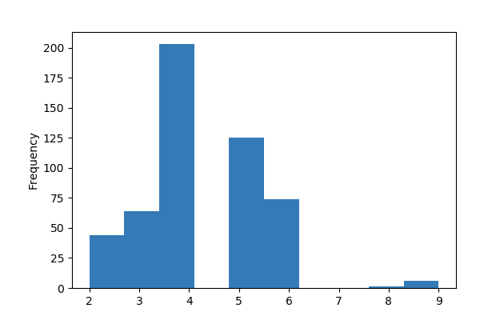

**Common Values**

| Value | Count | Frequency (%) |  |
| --- | --- | --- | --- |
| 4 | 203 | 39.3% |  |
| 5 | 125 | 24.2% |  |
| 6 | 74 | 14.3% |  |
| 3 | 64 | 12.4% |  |
| 2 | 44 | 8.5% |  |
| 9 | 6 | 1.2% |  |
| 8 | 1 | 0.2% |  |

**Extreme Values**

Minimum 5 values

| Value | Count | Frequency (%) |  |
| --- | --- | --- | --- |
| 2 | 44 | 8.5% |  |
| 3 | 64 | 12.4% |  |
| 4 | 203 | 39.3% |  |
| 5 | 125 | 24.2% |  |
| 6 | 74 | 14.3% |  |

Maximum 5 values

| Value | Count | Frequency (%) |  |
| --- | --- | --- | --- |
| 4 | 203 | 39.3% |  |
| 5 | 125 | 24.2% |  |
| 6 | 74 | 14.3% |  |
| 8 | 1 | 0.2% |  |
| 9 | 6 | 1.2% |  |

month  
Categorical

| Distinct count | 12 |
| --- | --- |
| Unique (%) | 2.3% |
| Missing (%) | 0.0% |
| Missing (n) | 0 |

| aug | 184 |
| --- | --- |
| sep | 172 |
| mar | 54 |
| Other values (9) | 107 |

Toggle details

| Value | Count | Frequency (%) |  |
| --- | --- | --- | --- |
| aug | 184 | 35.6% |  |
| sep | 172 | 33.3% |  |
| mar | 54 | 10.4% |  |
| jul | 32 | 6.2% |  |
| feb | 20 | 3.9% |  |
| jun | 17 | 3.3% |  |
| oct | 15 | 2.9% |  |
| dec | 9 | 1.7% |  |
| apr | 9 | 1.7% |  |
| jan | 2 | 0.4% |  |
| Other values (2) | 3 | 0.6% |  |

day  
Categorical

| Distinct count | 7 |
| --- | --- |
| Unique (%) | 1.4% |
| Missing (%) | 0.0% |
| Missing (n) | 0 |

| sun | 95 |
| --- | --- |
| fri | 85 |
| sat | 84 |
| Other values (4) | 253 |

Toggle details

| Value | Count | Frequency (%) |  |
| --- | --- | --- | --- |
| sun | 95 | 18.4% |  |
| fri | 85 | 16.4% |  |
| sat | 84 | 16.2% |  |
| mon | 74 | 14.3% |  |
| tue | 64 | 12.4% |  |
| thu | 61 | 11.8% |  |
| wed | 54 | 10.4% |  |

FFMC  
Numeric

| Distinct count | 106 |
| --- | --- |
| Unique (%) | 20.5% |
| Missing (%) | 0.0% |
| Missing (n) | 0 |
| Infinite (%) | 0.0% |
| Infinite (n) | 0 |

| Mean | 90.645 |
| --- | --- |
| Minimum | 18.7 |
| Maximum | 96.2 |
| Zeros (%) | 0.0% |

Toggle details

**Statistics**

Quantile statistics

| Minimum | 18.7 |
| --- | --- |
| 5-th percentile | 84.1 |
| Q1 | 90.2 |
| Median | 91.6 |
| Q3 | 92.9 |
| 95-th percentile | 95.1 |
| Maximum | 96.2 |
| Range | 77.5 |
| Interquartile range | 2.7 |

Descriptive statistics

| Standard deviation | 5.5201 |
| --- | --- |
| Coef of variation | 0.060898 |
| Kurtosis | 67.066 |
| Mean | 90.645 |
| MAD | 2.7721 |
| Skewness | -6.5756 |
| Sum | 46863 |
| Variance | 30.472 |
| Memory size | 4.2 KiB |

**Histogram**

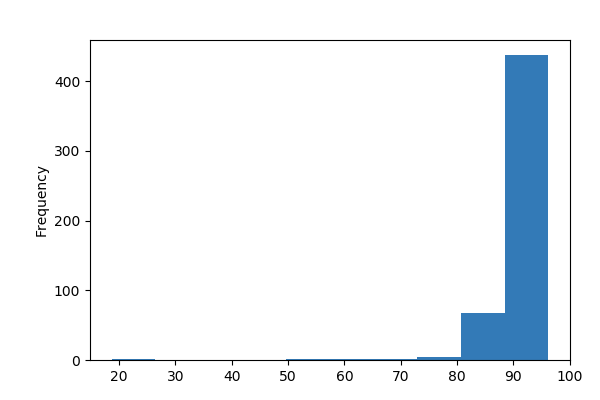

**Common Values**

| Value | Count | Frequency (%) |  |
| --- | --- | --- | --- |
| 91.6 | 28 | 5.4% |  |
| 92.1 | 28 | 5.4% |  |
| 91.0 | 22 | 4.3% |  |
| 91.7 | 19 | 3.7% |  |
| 93.7 | 16 | 3.1% |  |
| 92.4 | 16 | 3.1% |  |
| 92.5 | 15 | 2.9% |  |
| 94.8 | 14 | 2.7% |  |
| 90.2 | 12 | 2.3% |  |
| 90.1 | 12 | 2.3% |  |
| Other values (96) | 335 | 64.8% |  |

**Extreme Values**

Minimum 5 values

| Value | Count | Frequency (%) |  |
| --- | --- | --- | --- |
| 18.7 | 1 | 0.2% |  |
| 50.4 | 1 | 0.2% |  |
| 53.4 | 1 | 0.2% |  |
| 63.5 | 2 | 0.4% |  |
| 68.2 | 1 | 0.2% |  |

Maximum 5 values

| Value | Count | Frequency (%) |  |
| --- | --- | --- | --- |
| 95.8 | 1 | 0.2% |  |
| 95.9 | 2 | 0.4% |  |
| 96.0 | 2 | 0.4% |  |
| 96.1 | 6 | 1.2% |  |
| 96.2 | 2 | 0.4% |  |

DMC  
Numeric

| Distinct count | 215 |
| --- | --- |
| Unique (%) | 41.6% |
| Missing (%) | 0.0% |
| Missing (n) | 0 |
| Infinite (%) | 0.0% |
| Infinite (n) | 0 |

| Mean | 110.87 |
| --- | --- |
| Minimum | 1.1 |
| Maximum | 291.3 |
| Zeros (%) | 0.0% |

Toggle details

**Statistics**

Quantile statistics

| Minimum | 1.1 |
| --- | --- |
| 5-th percentile | 14.92 |
| Q1 | 68.6 |
| Median | 108.3 |
| Q3 | 142.4 |
| 95-th percentile | 231.1 |
| Maximum | 291.3 |
| Range | 290.2 |
| Interquartile range | 73.8 |

Descriptive statistics

| Standard deviation | 64.046 |
| --- | --- |
| Coef of variation | 0.57766 |
| Kurtosis | 0.20482 |
| Mean | 110.87 |
| MAD | 49.163 |
| Skewness | 0.5475 |
| Sum | 57321 |
| Variance | 4102 |
| Memory size | 4.2 KiB |

**Histogram**

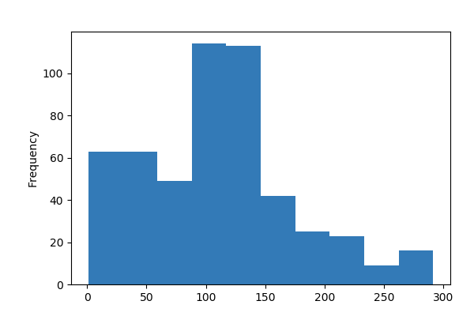

**Common Values**

| Value | Count | Frequency (%) |  |
| --- | --- | --- | --- |
| 99.0 | 10 | 1.9% |  |
| 129.5 | 9 | 1.7% |  |
| 142.4 | 8 | 1.5% |  |
| 231.1 | 8 | 1.5% |  |
| 137.0 | 7 | 1.4% |  |
| 126.5 | 7 | 1.4% |  |
| 108.4 | 7 | 1.4% |  |
| 108.3 | 7 | 1.4% |  |
| 35.8 | 7 | 1.4% |  |
| 117.9 | 6 | 1.2% |  |
| Other values (205) | 441 | 85.3% |  |

**Extreme Values**

Minimum 5 values

| Value | Count | Frequency (%) |  |
| --- | --- | --- | --- |
| 1.1 | 1 | 0.2% |  |
| 2.4 | 1 | 0.2% |  |
| 3.0 | 2 | 0.4% |  |
| 3.2 | 1 | 0.2% |  |
| 3.6 | 1 | 0.2% |  |

Maximum 5 values

| Value | Count | Frequency (%) |  |
| --- | --- | --- | --- |
| 276.3 | 4 | 0.8% |  |
| 284.9 | 1 | 0.2% |  |
| 287.2 | 1 | 0.2% |  |
| 290.0 | 4 | 0.8% |  |
| 291.3 | 1 | 0.2% |  |

DC  
Numeric

| Distinct count | 219 |
| --- | --- |
| Unique (%) | 42.4% |
| Missing (%) | 0.0% |
| Missing (n) | 0 |
| Infinite (%) | 0.0% |
| Infinite (n) | 0 |

| Mean | 547.94 |
| --- | --- |
| Minimum | 7.9 |
| Maximum | 860.6 |
| Zeros (%) | 0.0% |

Toggle details

**Statistics**

Quantile statistics

| Minimum | 7.9 |
| --- | --- |
| 5-th percentile | 43.58 |
| Q1 | 437.7 |
| Median | 664.2 |
| Q3 | 713.9 |
| 95-th percentile | 795.3 |
| Maximum | 860.6 |
| Range | 852.7 |
| Interquartile range | 276.2 |

Descriptive statistics

| Standard deviation | 248.07 |
| --- | --- |
| Coef of variation | 0.45273 |
| Kurtosis | -0.24524 |
| Mean | 547.94 |
| MAD | 203.69 |
| Skewness | -1.1004 |
| Sum | 283280 |
| Variance | 61537 |
| Memory size | 4.2 KiB |

**Histogram**

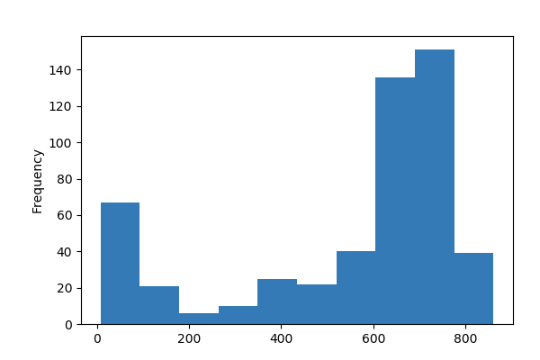

**Common Values**

| Value | Count | Frequency (%) |  |
| --- | --- | --- | --- |
| 745.3 | 10 | 1.9% |  |
| 692.6 | 9 | 1.7% |  |
| 698.6 | 8 | 1.5% |  |
| 601.4 | 8 | 1.5% |  |
| 692.3 | 8 | 1.5% |  |
| 715.1 | 8 | 1.5% |  |
| 647.1 | 7 | 1.4% |  |
| 686.5 | 7 | 1.4% |  |
| 706.4 | 7 | 1.4% |  |
| 80.8 | 7 | 1.4% |  |
| Other values (209) | 438 | 84.7% |  |

**Extreme Values**

Minimum 5 values

| Value | Count | Frequency (%) |  |
| --- | --- | --- | --- |
| 7.9 | 1 | 0.2% |  |
| 9.3 | 1 | 0.2% |  |
| 15.3 | 1 | 0.2% |  |
| 15.5 | 1 | 0.2% |  |
| 15.8 | 1 | 0.2% |  |

Maximum 5 values

| Value | Count | Frequency (%) |  |
| --- | --- | --- | --- |
| 825.1 | 4 | 0.8% |  |
| 844.0 | 1 | 0.2% |  |
| 849.3 | 1 | 0.2% |  |
| 855.3 | 4 | 0.8% |  |
| 860.6 | 1 | 0.2% |  |

ISI  
Numeric

| Distinct count | 119 |
| --- | --- |
| Unique (%) | 23.0% |
| Missing (%) | 0.0% |
| Missing (n) | 0 |
| Infinite (%) | 0.0% |
| Infinite (n) | 0 |

| Mean | 9.0217 |
| --- | --- |
| Minimum | 0 |
| Maximum | 56.1 |
| Zeros (%) | 0.2% |

Toggle details

**Statistics**

Quantile statistics

| Minimum | 0 |
| --- | --- |
| 5-th percentile | 2.6 |
| Q1 | 6.5 |
| Median | 8.4 |
| Q3 | 10.8 |
| 95-th percentile | 17 |
| Maximum | 56.1 |
| Range | 56.1 |
| Interquartile range | 4.3 |

Descriptive statistics

| Standard deviation | 4.5595 |
| --- | --- |
| Coef of variation | 0.50539 |
| Kurtosis | 21.458 |
| Mean | 9.0217 |
| MAD | 3.1807 |
| Skewness | 2.5363 |
| Sum | 4664.2 |
| Variance | 20.789 |
| Memory size | 4.2 KiB |

**Histogram**

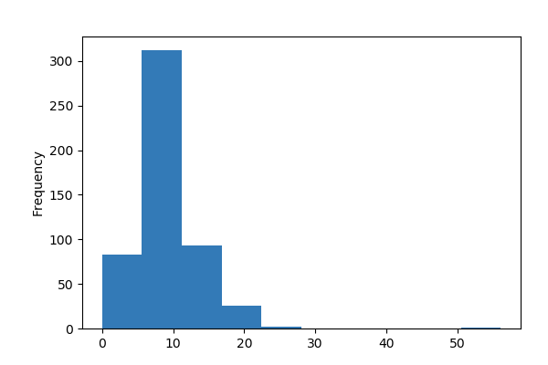

**Common Values**

| Value | Count | Frequency (%) |  |
| --- | --- | --- | --- |
| 9.6 | 23 | 4.4% |  |
| 7.1 | 21 | 4.1% |  |
| 6.3 | 20 | 3.9% |  |
| 7.0 | 17 | 3.3% |  |
| 8.4 | 17 | 3.3% |  |
| 6.2 | 16 | 3.1% |  |
| 9.2 | 15 | 2.9% |  |
| 7.5 | 14 | 2.7% |  |
| 8.1 | 12 | 2.3% |  |
| 7.8 | 12 | 2.3% |  |
| Other values (109) | 350 | 67.7% |  |

**Extreme Values**

Minimum 5 values

| Value | Count | Frequency (%) |  |
| --- | --- | --- | --- |
| 0.0 | 1 | 0.2% |  |
| 0.4 | 2 | 0.4% |  |
| 0.7 | 1 | 0.2% |  |
| 0.8 | 3 | 0.6% |  |
| 1.1 | 1 | 0.2% |  |

Maximum 5 values

| Value | Count | Frequency (%) |  |
| --- | --- | --- | --- |
| 20.3 | 4 | 0.8% |  |
| 21.3 | 1 | 0.2% |  |
| 22.6 | 1 | 0.2% |  |
| 22.7 | 1 | 0.2% |  |
| 56.1 | 1 | 0.2% |  |

temp  
Numeric

| Distinct count | 192 |
| --- | --- |
| Unique (%) | 37.1% |
| Missing (%) | 0.0% |
| Missing (n) | 0 |
| Infinite (%) | 0.0% |
| Infinite (n) | 0 |

| Mean | 18.889 |
| --- | --- |
| Minimum | 2.2 |
| Maximum | 33.3 |
| Zeros (%) | 0.0% |

Toggle details

**Statistics**

Quantile statistics

| Minimum | 2.2 |
| --- | --- |
| 5-th percentile | 8.2 |
| Q1 | 15.5 |
| Median | 19.3 |
| Q3 | 22.8 |
| 95-th percentile | 27.9 |
| Maximum | 33.3 |
| Range | 31.1 |
| Interquartile range | 7.3 |

Descriptive statistics

| Standard deviation | 5.8066 |
| --- | --- |
| Coef of variation | 0.30741 |
| Kurtosis | 0.13617 |
| Mean | 18.889 |
| MAD | 4.51 |
| Skewness | -0.33117 |
| Sum | 9765.7 |
| Variance | 33.717 |
| Memory size | 4.2 KiB |

**Histogram**

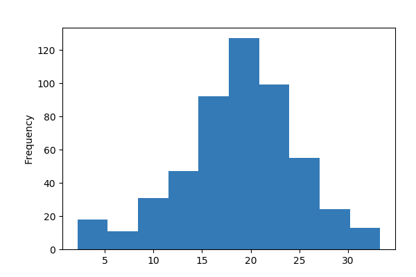

**Common Values**

| Value | Count | Frequency (%) |  |
| --- | --- | --- | --- |
| 17.4 | 8 | 1.5% |  |
| 19.6 | 8 | 1.5% |  |
| 15.4 | 7 | 1.4% |  |
| 20.6 | 7 | 1.4% |  |
| 23.4 | 6 | 1.2% |  |
| 21.6 | 6 | 1.2% |  |
| 17.8 | 6 | 1.2% |  |
| 18.9 | 6 | 1.2% |  |
| 20.7 | 6 | 1.2% |  |
| 19.1 | 6 | 1.2% |  |
| Other values (182) | 451 | 87.2% |  |

**Extreme Values**

Minimum 5 values

| Value | Count | Frequency (%) |  |
| --- | --- | --- | --- |
| 2.2 | 1 | 0.2% |  |
| 4.2 | 1 | 0.2% |  |
| 4.6 | 6 | 1.2% |  |
| 4.8 | 1 | 0.2% |  |
| 5.1 | 5 | 1.0% |  |

Maximum 5 values

| Value | Count | Frequency (%) |  |
| --- | --- | --- | --- |
| 32.3 | 1 | 0.2% |  |
| 32.4 | 2 | 0.4% |  |
| 32.6 | 1 | 0.2% |  |
| 33.1 | 1 | 0.2% |  |
| 33.3 | 1 | 0.2% |  |

RH  
Numeric

| Distinct count | 75 |
| --- | --- |
| Unique (%) | 14.5% |
| Missing (%) | 0.0% |
| Missing (n) | 0 |
| Infinite (%) | 0.0% |
| Infinite (n) | 0 |

| Mean | 44.288 |
| --- | --- |
| Minimum | 15 |
| Maximum | 100 |
| Zeros (%) | 0.0% |

Toggle details

**Statistics**

Quantile statistics

| Minimum | 15 |
| --- | --- |
| 5-th percentile | 24 |
| Q1 | 33 |
| Median | 42 |
| Q3 | 53 |
| 95-th percentile | 77 |
| Maximum | 100 |
| Range | 85 |
| Interquartile range | 20 |

Descriptive statistics

| Standard deviation | 16.317 |
| --- | --- |
| Coef of variation | 0.36844 |
| Kurtosis | 0.43818 |
| Mean | 44.288 |
| MAD | 12.843 |
| Skewness | 0.8629 |
| Sum | 22897 |
| Variance | 266.26 |
| Memory size | 4.2 KiB |

**Histogram**

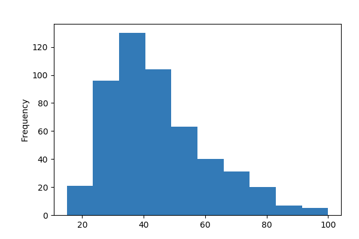

**Common Values**

| Value | Count | Frequency (%) |  |
| --- | --- | --- | --- |
| 27.0 | 33 | 6.4% |  |
| 39.0 | 24 | 4.6% |  |
| 35.0 | 20 | 3.9% |  |
| 43.0 | 17 | 3.3% |  |
| 42.0 | 17 | 3.3% |  |
| 45.0 | 16 | 3.1% |  |
| 34.0 | 16 | 3.1% |  |
| 33.0 | 15 | 2.9% |  |
| 40.0 | 15 | 2.9% |  |
| 46.0 | 14 | 2.7% |  |
| Other values (65) | 330 | 63.8% |  |

**Extreme Values**

Minimum 5 values

| Value | Count | Frequency (%) |  |
| --- | --- | --- | --- |
| 15.0 | 2 | 0.4% |  |
| 17.0 | 1 | 0.2% |  |
| 18.0 | 1 | 0.2% |  |
| 19.0 | 4 | 0.8% |  |
| 20.0 | 1 | 0.2% |  |

Maximum 5 values

| Value | Count | Frequency (%) |  |
| --- | --- | --- | --- |
| 94.0 | 1 | 0.2% |  |
| 96.0 | 1 | 0.2% |  |
| 97.0 | 1 | 0.2% |  |
| 99.0 | 1 | 0.2% |  |
| 100.0 | 1 | 0.2% |  |

wind  
Numeric

| Distinct count | 21 |
| --- | --- |
| Unique (%) | 4.1% |
| Missing (%) | 0.0% |
| Missing (n) | 0 |
| Infinite (%) | 0.0% |
| Infinite (n) | 0 |

| Mean | 4.0176 |
| --- | --- |
| Minimum | 0.4 |
| Maximum | 9.4 |
| Zeros (%) | 0.0% |

Toggle details

**Statistics**

Quantile statistics

| Minimum | 0.4 |
| --- | --- |
| 5-th percentile | 1.3 |
| Q1 | 2.7 |
| Median | 4 |
| Q3 | 4.9 |
| 95-th percentile | 7.6 |
| Maximum | 9.4 |
| Range | 9 |
| Interquartile range | 2.2 |

Descriptive statistics

| Standard deviation | 1.7917 |
| --- | --- |
| Coef of variation | 0.44595 |
| Kurtosis | 0.054324 |
| Mean | 4.0176 |
| MAD | 1.4371 |
| Skewness | 0.571 |
| Sum | 2077.1 |
| Variance | 3.21 |
| Memory size | 4.2 KiB |

**Histogram**

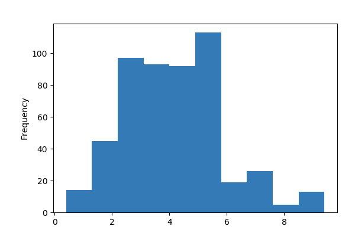

**Common Values**

| Value | Count | Frequency (%) |  |
| --- | --- | --- | --- |
| 2.2 | 53 | 10.3% |  |
| 3.1 | 53 | 10.3% |  |
| 4.0 | 51 | 9.9% |  |
| 4.9 | 48 | 9.3% |  |
| 2.7 | 44 | 8.5% |  |
| 4.5 | 41 | 7.9% |  |
| 5.4 | 41 | 7.9% |  |
| 3.6 | 40 | 7.7% |  |
| 1.8 | 31 | 6.0% |  |
| 5.8 | 24 | 4.6% |  |
| Other values (11) | 91 | 17.6% |  |

**Extreme Values**

Minimum 5 values

| Value | Count | Frequency (%) |  |
| --- | --- | --- | --- |
| 0.4 | 1 | 0.2% |  |
| 0.9 | 13 | 2.5% |  |
| 1.3 | 14 | 2.7% |  |
| 1.8 | 31 | 6.0% |  |
| 2.2 | 53 | 10.3% |  |

Maximum 5 values

| Value | Count | Frequency (%) |  |
| --- | --- | --- | --- |
| 7.6 | 14 | 2.7% |  |
| 8.0 | 5 | 1.0% |  |
| 8.5 | 8 | 1.5% |  |
| 8.9 | 1 | 0.2% |  |
| 9.4 | 4 | 0.8% |  |

rain  
Numeric

| Distinct count | 7 |
| --- | --- |
| Unique (%) | 1.4% |
| Missing (%) | 0.0% |
| Missing (n) | 0 |
| Infinite (%) | 0.0% |
| Infinite (n) | 0 |

| Mean | 0.021663 |
| --- | --- |
| Minimum | 0 |
| Maximum | 6.4 |
| Zeros (%) | 98.5% |

Toggle details

**Statistics**

Quantile statistics

| Minimum | 0 |
| --- | --- |
| 5-th percentile | 0 |
| Q1 | 0 |
| Median | 0 |
| Q3 | 0 |
| 95-th percentile | 0 |
| Maximum | 6.4 |
| Range | 6.4 |
| Interquartile range | 0 |

Descriptive statistics

| Standard deviation | 0.29596 |
| --- | --- |
| Coef of variation | 13.662 |
| Kurtosis | 421.3 |
| Mean | 0.021663 |
| MAD | 0.042656 |
| Skewness | 19.816 |
| Sum | 11.2 |
| Variance | 0.087592 |
| Memory size | 4.2 KiB |

**Histogram**

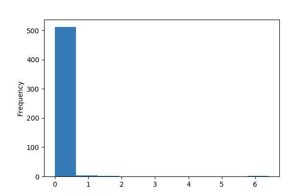

**Common Values**

| Value | Count | Frequency (%) |  |
| --- | --- | --- | --- |
| 0.0 | 509 | 98.5% |  |
| 0.8 | 2 | 0.4% |  |
| 0.2 | 2 | 0.4% |  |
| 0.4 | 1 | 0.2% |  |
| 6.4 | 1 | 0.2% |  |
| 1.4 | 1 | 0.2% |  |
| 1.0 | 1 | 0.2% |  |

**Extreme Values**

Minimum 5 values

| Value | Count | Frequency (%) |  |
| --- | --- | --- | --- |
| 0.0 | 509 | 98.5% |  |
| 0.2 | 2 | 0.4% |  |
| 0.4 | 1 | 0.2% |  |
| 0.8 | 2 | 0.4% |  |
| 1.0 | 1 | 0.2% |  |

Maximum 5 values

| Value | Count | Frequency (%) |  |
| --- | --- | --- | --- |
| 0.4 | 1 | 0.2% |  |
| 0.8 | 2 | 0.4% |  |
| 1.0 | 1 | 0.2% |  |
| 1.4 | 1 | 0.2% |  |
| 6.4 | 1 | 0.2% |  |

area  
Numeric

| Distinct count | 251 |
| --- | --- |
| Unique (%) | 48.5% |
| Missing (%) | 0.0% |
| Missing (n) | 0 |
| Infinite (%) | 0.0% |
| Infinite (n) | 0 |

| Mean | 12.847 |
| --- | --- |
| Minimum | 0 |
| Maximum | 1090.8 |
| Zeros (%) | 47.8% |

Toggle details

**Statistics**

Quantile statistics

| Minimum | 0 |
| --- | --- |
| 5-th percentile | 0 |
| Q1 | 0 |
| Median | 0.52 |
| Q3 | 6.57 |
| 95-th percentile | 48.714 |
| Maximum | 1090.8 |
| Range | 1090.8 |
| Interquartile range | 6.57 |

Descriptive statistics

| Standard deviation | 63.656 |
| --- | --- |
| Coef of variation | 4.9548 |
| Kurtosis | 194.14 |
| Mean | 12.847 |
| MAD | 18.567 |
| Skewness | 12.847 |
| Sum | 6642 |
| Variance | 4052.1 |
| Memory size | 4.2 KiB |

**Histogram**

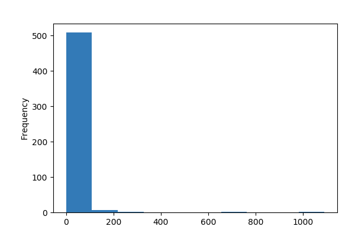

**Common Values**

| Value | Count | Frequency (%) |  |
| --- | --- | --- | --- |
| 0.0 | 247 | 47.8% |  |
| 1.94 | 3 | 0.6% |  |
| 3.71 | 2 | 0.4% |  |
| 0.9 | 2 | 0.4% |  |
| 1.95 | 2 | 0.4% |  |
| 2.14 | 2 | 0.4% |  |
| 2.18 | 2 | 0.4% |  |
| 1.56 | 2 | 0.4% |  |
| 9.96 | 2 | 0.4% |  |
| 28.66 | 2 | 0.4% |  |
| Other values (241) | 251 | 48.5% |  |

**Extreme Values**

Minimum 5 values

| Value | Count | Frequency (%) |  |
| --- | --- | --- | --- |
| 0.0 | 247 | 47.8% |  |
| 0.09 | 1 | 0.2% |  |
| 0.17 | 1 | 0.2% |  |
| 0.21 | 1 | 0.2% |  |
| 0.24 | 1 | 0.2% |  |

Maximum 5 values

| Value | Count | Frequency (%) |  |
| --- | --- | --- | --- |
| 200.94 | 1 | 0.2% |  |
| 212.88 | 1 | 0.2% |  |
| 278.53 | 1 | 0.2% |  |
| 746.28 | 1 | 0.2% |  |
| 1090.84 | 1 | 0.2% |  |

# Correlations

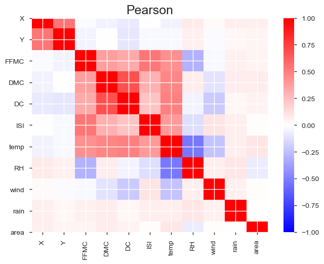

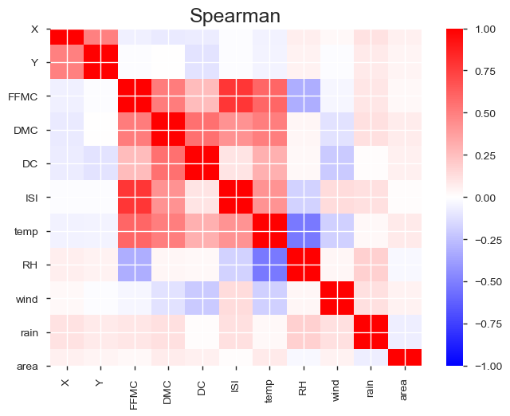

# Sample

|  | X | Y | month | day | FFMC | DMC | DC | ISI | temp | RH | wind | rain | area |
| --- | --- | --- | --- | --- | --- | --- | --- | --- | --- | --- | --- | --- | --- |
| 0 | 7 | 5 | mar | fri | 86.2 | 26.2 | 94.3 | 5.1 | 8.2 | 51.0 | 6.7 | 0.0 | 0.0 |
| 1 | 7 | 4 | oct | tue | 90.6 | 35.4 | 669.1 | 6.7 | 18.0 | 33.0 | 0.9 | 0.0 | 0.0 |
| 2 | 7 | 4 | oct | sat | 90.6 | 43.7 | 686.9 | 6.7 | 14.6 | 33.0 | 1.3 | 0.0 | 0.0 |
| 3 | 8 | 6 | mar | fri | 91.7 | 33.3 | 77.5 | 9.0 | 8.3 | 97.0 | 4.0 | 0.2 | 0.0 |
| 4 | 8 | 6 | mar | sun | 89.3 | 51.3 | 102.2 | 9.6 | 11.4 | 99.0 | 1.8 | 0.0 | 0.0 |